# Distribuir plantilla de proyecto

En las clases pasadas ya aprendimos la estructura de las plantillas; es decir toda el árbol y estructura de archivos que queremos reproducir una y otra vez, también aprendimos sobre **hooks**; es decir las acciones que se van a ejecutar antes y después de la creación de este nuevo proyecto.

Ahora es momento de guardar mi plantilla para que siempre este disponible cuando la requiera usar.

Vamos a realizarlo con GitHub. Así que vayamos a un repositorio

### Crear nuevo repositorio

1. Dar un nombre a la plantilla (Repositorio)
2. Definir repositorio [Publico - Privado]
3. Escoger si queremos que crear algún archivo [README.md - .gitignore - License] de momento lo ignoramos.
4. Crear repositorio

Me van a aparecer las siguientes opciones:

#### **Create a new repository on the command line**

```
git
echo "# cookiecutter_template" >> README.md
git init
git add README.md
git commit -m "first commit"
git branch -M main
git remote add origin git@github.com:DensLopez/cookiecutter_template.git
git push -u origin main
```

#### **Push an existing repository from the command line**

```
git
git remote add origin git@github.com:DensLopez/cookiecutter_template.git
git branch -M main
git push -u origin main
```

### Crear repositorio y añadir el origen de repositorio a nuestra plantilla

Hay que proceder a posicionarnos en `/cookiecutter-personal` y crear un repositorio de git

```
cd cookiecutter-personal
#Inicializar repositorio
git init
#verificar el estado del repositorio
git status
#agregar todos los archivos de esta carpeta
git add .
#checamos nuevamente el estado
git status
#primer commit
git commit -m "Initial commit"
```

Ahora ya que existe un repositorio vamos a ejecutar lo que nos decía el repositorio en GitHub

```
#añade el origen del repositorio de GitHub
#a mi repositorio local
git remote add origin git@github.com:DensLopez/cookiecutter_template.git
#renombra la rama actual como "main"
git branch -M main
#envia el contenido de la rama "main" a GitHub
git push -u origin main
```

Listo!! Tenemos nuestra plantilla Online:

[figure not shown]

Pero si abrimos las carpetas nos damos cuenta que no ha copiado unas carpetas, esto se debe a que git automáticamente no sube las carpetas sino existe un contenido dentro de ellas. Es decir no detecta carpetas vacías y por lo tanto no las va a trackear.

**¿Cómo hago para conservar las carpetas?** Lo que haré será añadir un archivo a `.gitkeep` a cada carpeta que necesite en mi repositorio.

Así que procederemos a hacerlo y actualizar mi versión de GitHub.

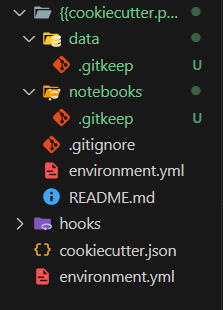

```
#Ver el estado de mi repositorio local
git status
#Añadir los archivos modificados
git add .
#Crear un commit con mensaje
git commit -m "Añadiendo carpetas vacías"
#Traer los archivos del repositorio remoto
git pull origin main
#Subir los cambios a GitHub
git push origin main
```

Esto me asegurará crear de manera certera y eficiente mi plantilla.

### ¿Cómo puedo traer mi plantilla desde Git Hub?

Selecciono la dirección web de mi repositorio y la copio:

`https://github.com/DensLopez/cookiecutter_template/tree/main`

Ahora procedo a abrir una terminal, y dado que en este caso mi template esta en la rama principal, no se necesita hacer una configuración adicional. Así que ejecutemos lo siguiente:

```
#verificamos que estemos en el entorno que tenga cookiecutter
conda env list
#activamos el entorno
conda activate cookiecutter
#Pegamos la dirección
cookiecutter https://github.com/DensLopez/cookiecutter_template
```

Una vez que ejecutamos, rellenamos los campos y vemos que se crea nuestro template

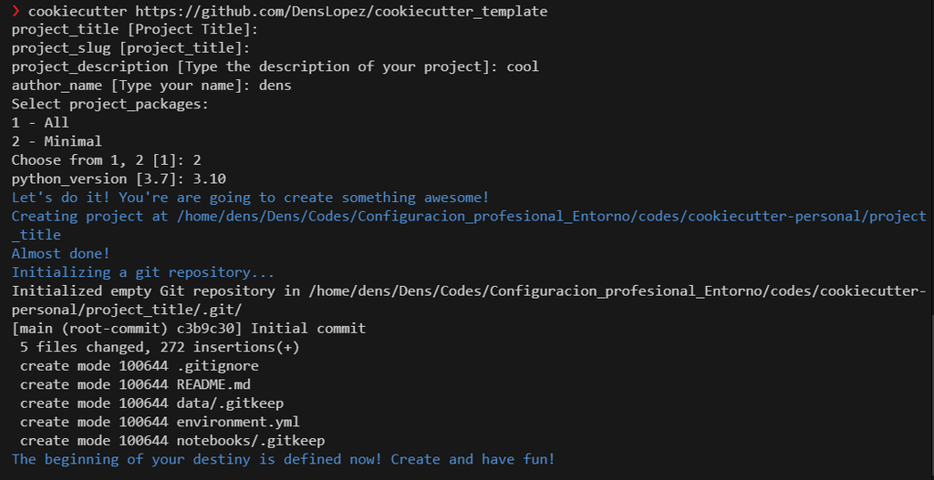

Aquí nos genero un proyecto con los parámetros asignados y manteniendo todas las carpetas como las hemos creado:

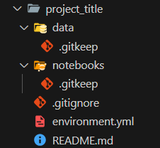

Ahora podemos checarlo con Visual Studio Code:

```
#Verificar la carpeta del proyecto
code project_title/
```

[figure not shown]

De esta forma podemos usar cookiecutter para distribuir plantillas, así también podemos encontrar [plantillas en Git Hub](https://github.com/search?q=cookiecutter&type=repositories) que usen cookiecutter.